## Assignment 8

#### By Brian Weinfeld

##### April 26th, 2018

### mySQL to Neo4j

I decided to revist the mySQL tables created in assignment number 2. In that assignment, I asked all my students to review the top six movies of 2017 on a scale from 1 to 5. The data was read into R, tidied and written directly to an SQL database.

For this project, I will read in the data, create a Neo4j graph and use the graph to make recommendations for my students.

```r
mydb <- dbConnect(MySQL(), user='root',
                  password=sql.password,
                  dbname='week2assignment',
                  host='localhost')

all.data <- dbSendQuery(mydb, 'SELECT users.user_id AS id, users.email, reviews.movie AS title,
                               reviews.rating FROM users
                               JOIN reviews ON users.user_id = reviews.user_id'
                        ) %>%
  fetch() %>%
  filter(!is.na(rating))
all.data[1:10, ] %>% kable()
```

| id | email | title | rating |
| --- | --- | --- | --- |
| 1 | Redacted Unique 1 | STAR WARS THE LAST JEDI | 3 |
| 1 | Redacted Unique 1 | BEAUTY AND THE BEAST 2017 | 1 |
| 1 | Redacted Unique 1 | WONDER WOMAN | 2 |
| 1 | Redacted Unique 1 | GUARDIANS OF THE GALAXY VOL 2 | 3 |
| 1 | Redacted Unique 1 | JUMANJI WELCOME TO THE JUNGLE | 3 |
| 1 | Redacted Unique 1 | SPIDER MAN HOMECOMING | 4 |
| 2 | Redacted Unique 2 | STAR WARS THE LAST JEDI | 5 |
| 2 | Redacted Unique 2 | BEAUTY AND THE BEAST 2017 | 4 |
| 2 | Redacted Unique 2 | JUMANJI WELCOME TO THE JUNGLE | 5 |
| 3 | Redacted Unique 3 | STAR WARS THE LAST JEDI | 5 |

Each line represents one student’s review of one movie. Movie that they have not reviewed were stored in the SQL database but have been removed here as they will not be represented in the Neo4j graph.

```r
graph <- startGraph('http://localhost:7474/db/data/', username='neo4j', password=neo4j.password)

addConstraint(graph, 'User', 'email')
addConstraint(graph, 'User', 'id')
addConstraint(graph, 'Movie', 'title')
```

```r
query <- '
MERGE (user:User {id: {id}, email:{email}})
MERGE (movie:Movie {title: {title}})
CREATE (user)-[r:REVIEWS]->(movie)
SET r.rating = TOINT({rating})
'
tx <- newTransaction(graph)

for(i in 1:nrow(all.data)){
  row <- all.data[i, ]
  appendCypher(tx, query,
               email = row$email,
               id = row$id,
               rating = row$rating,
               title = row$title)
}

commit(tx)

summary(graph)
```

```
##   This      To  That
## 1 User REVIEWS Movie
```

The above script inserts all the user and movie nodes and makes the appropriate review connections. Each connection has a rating attribute. After running the script, my Neo4j graph is ready for querying. The complete graph is below.

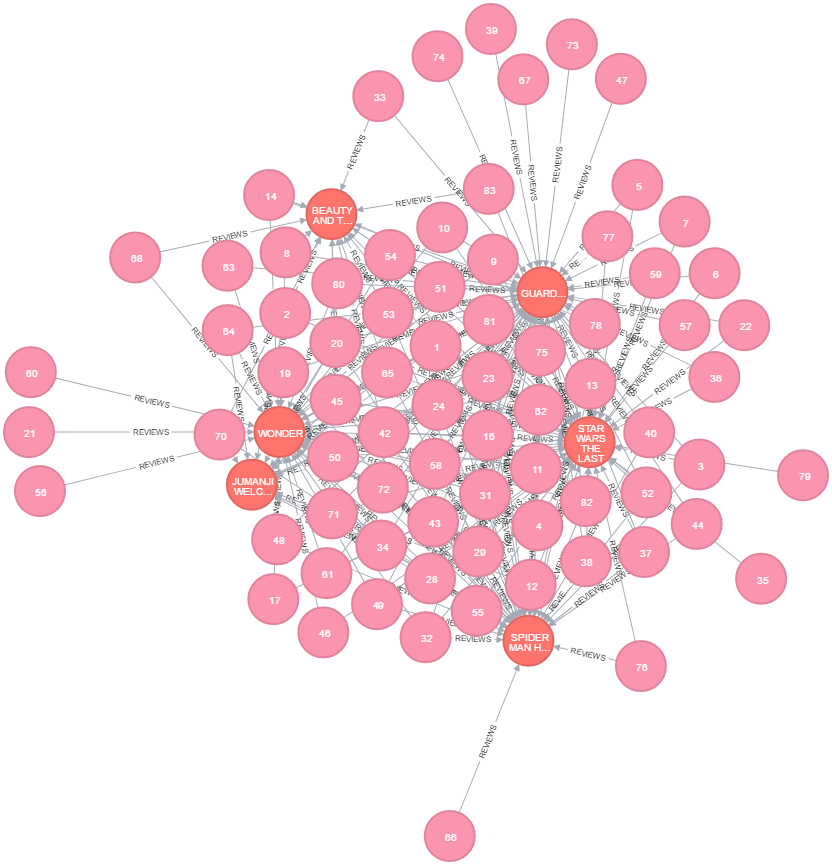

### Querying

I began with a simple query designed to identify count all the identical ratings between every pair of users.

```r
cypher.query <- cypher(graph, 'MATCH (u:User)-[r:REVIEWS]->(m:Movie),
                       (u2:User)-[r2:REVIEWS]->(m:Movie)
                       WHERE u.id <> u2.id
                       AND r.rating = r2.rating
                       RETURN u.id, u2.id, COUNT(*) AS count;') %>%
  group_by(u.id) %>%
  filter(count == max(count)) %>%
  arrange(u.id, u2.id)
cypher.query[seq(1, 101, 10), ] %>% kable()
```

| u.id | u2.id | count |
| --- | --- | --- |
| 1 | 4 | 2 |
| 1 | 78 | 2 |
| 4 | 1 | 2 |
| 4 | 75 | 2 |
| 5 | 65 | 2 |
| 8 | 43 | 2 |
| 12 | 20 | 3 |
| 14 | 33 | 2 |
| 19 | 10 | 2 |
| 19 | 75 | 2 |
| 21 | 24 | 1 |

I decided to build on this by making a very basic recommendor system. I created a function that accepts a user id and displays movie recommendations. This works by making two queries to my Neo4j graph. The first identifies all the users who share the largest number of identical ratings as the indicated user. The second query finds all the movies the indentified users have seen that the original user hasn’t and returns them ordered by the average score those users gave the movie.

```r
Recommendation <- function(id){
  best.matches <- cypher(graph, 'MATCH (u:User {id: {id}})-[r:REVIEWS]->(m:Movie),
                                 (u2:User)-[r2:REVIEWS]->(m:Movie)
                                 WHERE u.id <> u2.id
                                 AND r.rating = r2.rating
                                 RETURN u2.id, COUNT(*) AS count;',
                         id=id) %>%
    filter(count == max(count)) %>%
    select(u2.id) %>%
    unlist() %>%
    as.numeric()
  if(length(best.matches) == 0){
    print('You have no similar users!')
    return
  }
  recs <- cypher(graph, 'MATCH (u2:User)-[r2:REVIEWS]->(m2:Movie)
                         WHERE u2.id IN {best}
                         AND NOT((:User {id:{id}})-[:REVIEWS]->(m2))
                         RETURN m2.title, AVG(r2.rating) AS avg
                         ORDER BY avg DESC',
                 id = id,
                 best = best.matches)
  if(is.null(recs)){
    print('Your similar users have no suggestions!')
    return
  }
  print('Recommendations:')
  print(recs)
}

output <- Recommendation(64)
```

```
## [1] "Recommendations:"
##                  m2.title avg
## 1   SPIDER MAN HOMECOMING 5.0
## 2 STAR WARS THE LAST JEDI 3.5
```

This recommendor system is incredibly basic and has many shortcomings that should be improved before being used to make serious recommendations. However, as a proof of concept, it is able to query the appropriate information. The below graph provides a visual of the indicated user (64) and the recommendations made by the system.

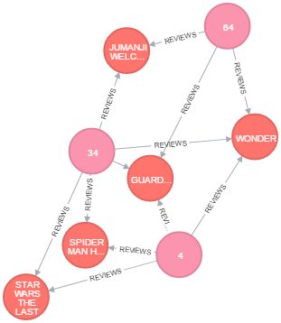

The data has been successfully transfered from mySQL to RNeo4j via R and has been successfully queried. A small recommendation system has been created as a proof of concept.